# Data Science Methods for Economics and Finance 871 Final Project: Predicting Chess Outcomes

Abstract

Chess is one of the most complicated games in the world. Humans on the other hand are not so complicated and we are the ones playing the game. This made me ask the question: “Is it possible to predict a game of chess based on just on data on the players before the game has started and just the openings used?” I employ an extreme gradient boosting model to answer this question and find that I can only predict the outcome with just over 60% accuracy, which is double the chances of just guessing.

# Introduction

Chess is one of, if not the most, popular games in the world. In recent years it has gained even more popularity from the entertainment industry with the hit TV show “Queen’s Gambit” and movie “Pawn”

Chess can be broken down into three stages of the game: the opening, the middlegame and the endgame.

# Exploratory Data Investigation

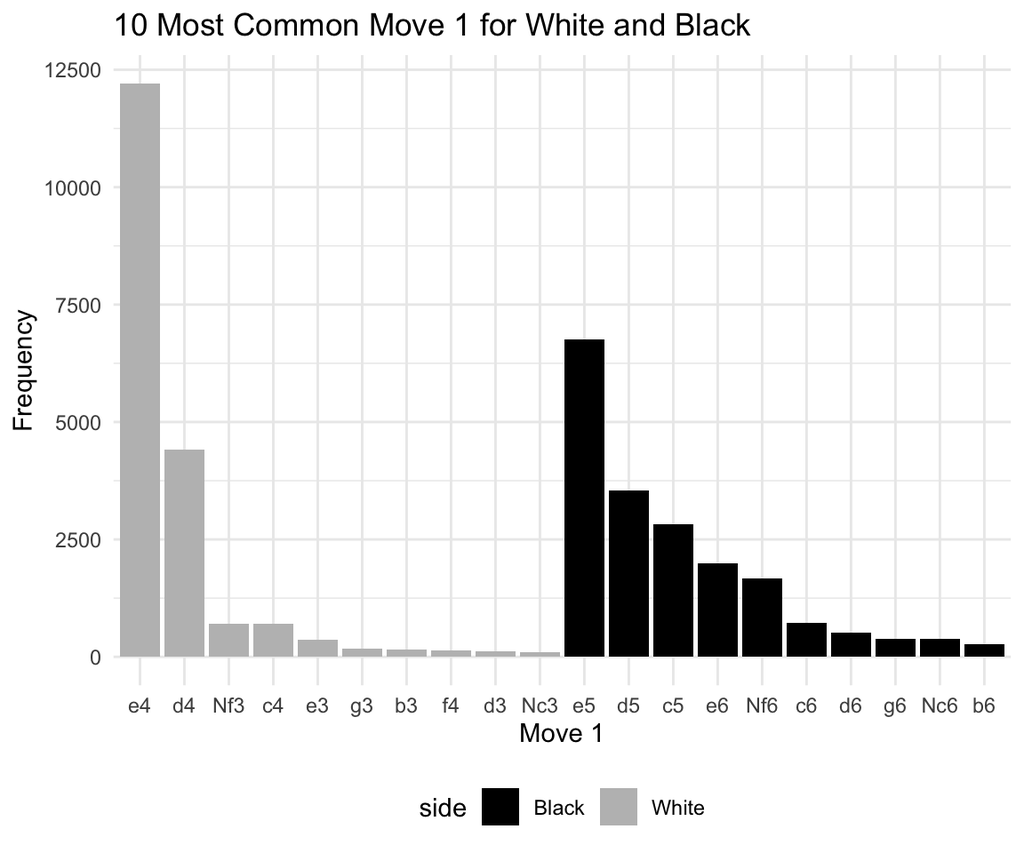

Most Common Opening Moves by Colour

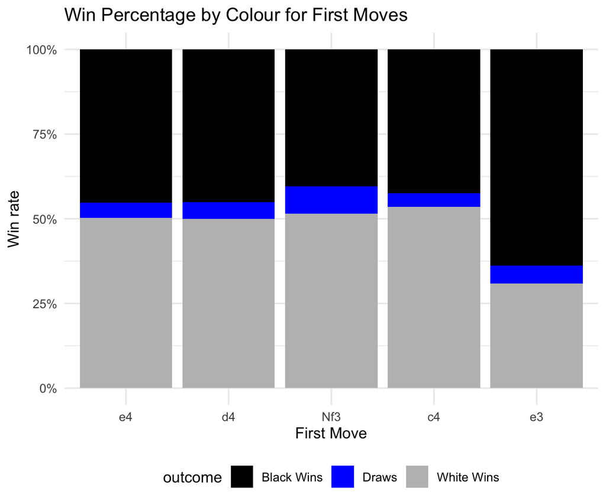

Proportions of Outcomes by White First Move

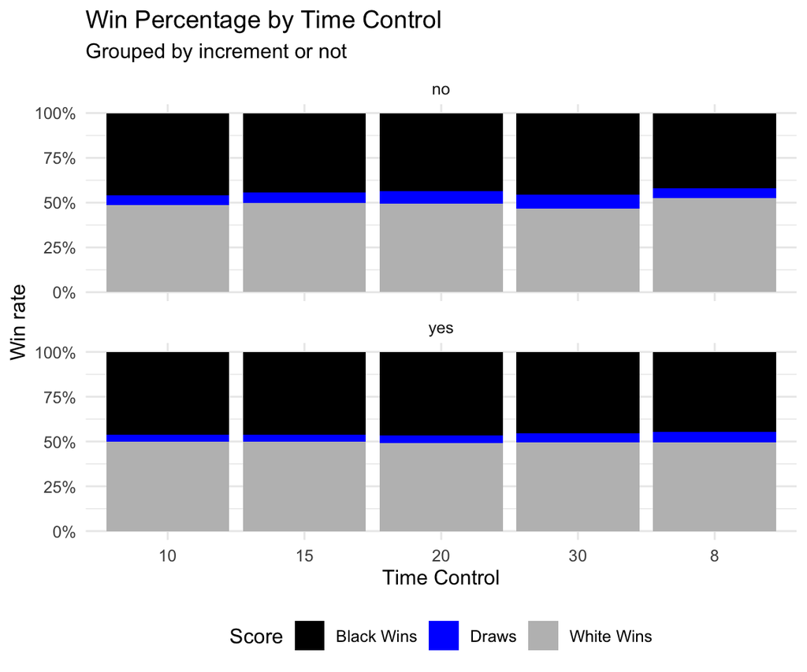

Outcomes by Time Controls

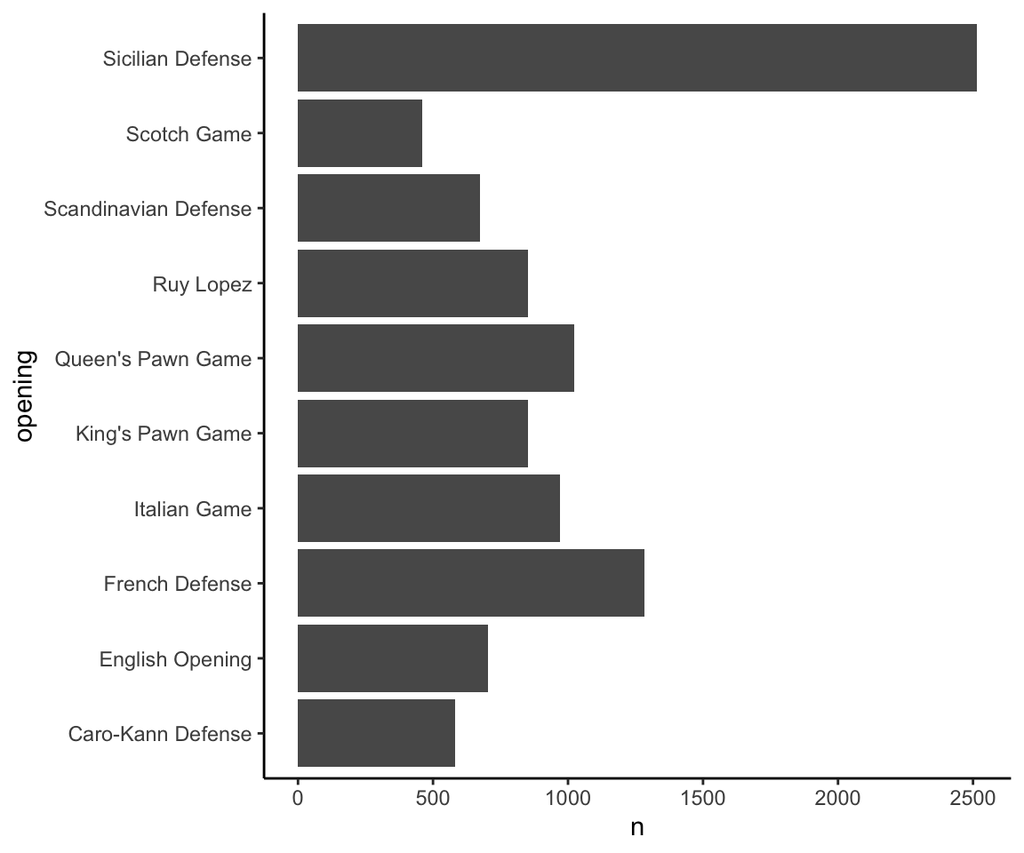

Most Popular Openings

[figure not shown]

Outcome by Popular Openings

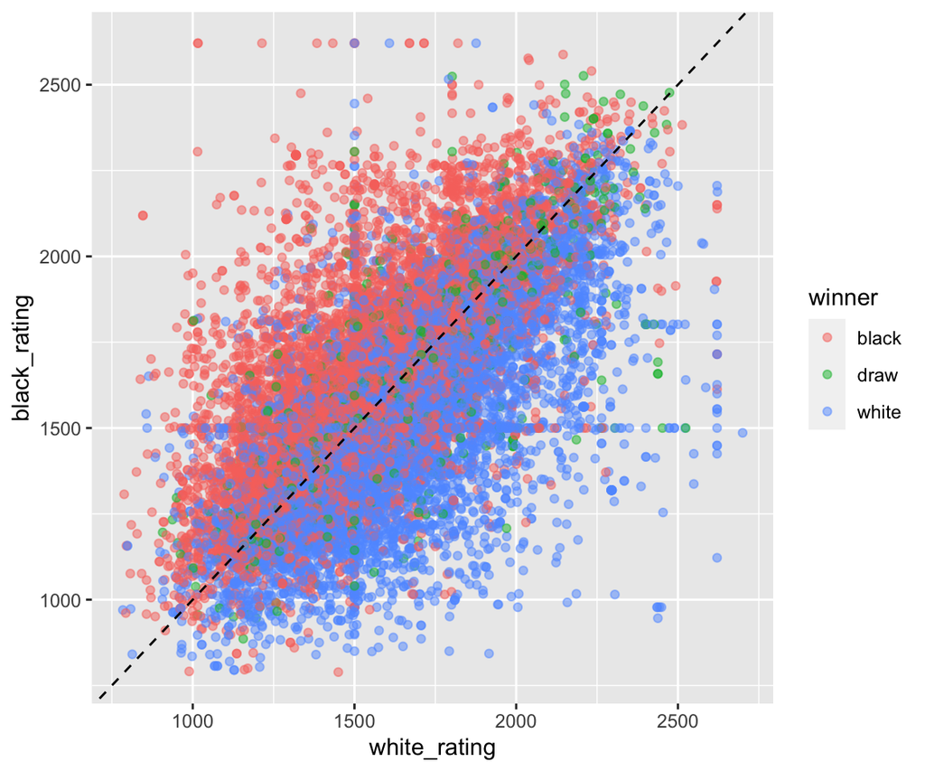

Outcomes and Ratings

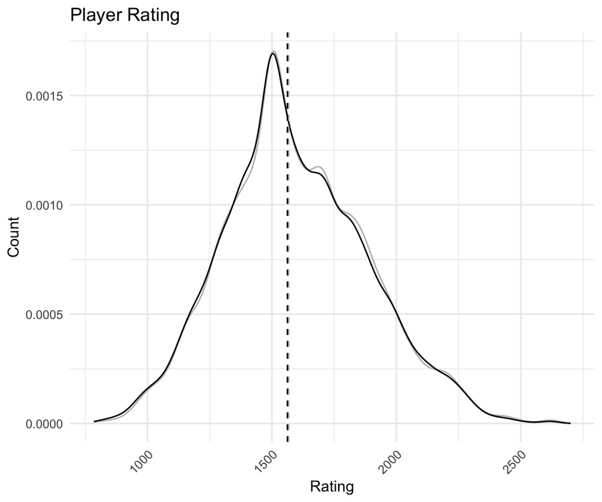

Distribution of Ratings

# Results

## Full Sample

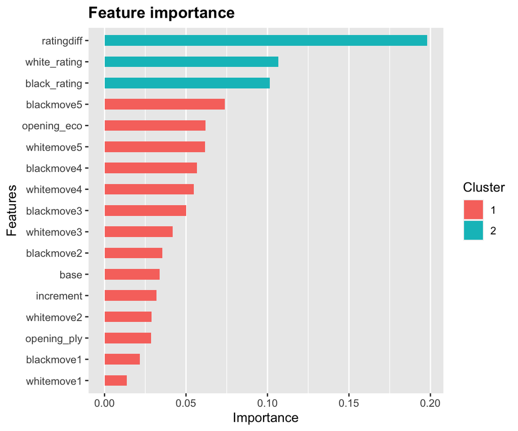

Importance of Features for Untuned Model: Full Sample

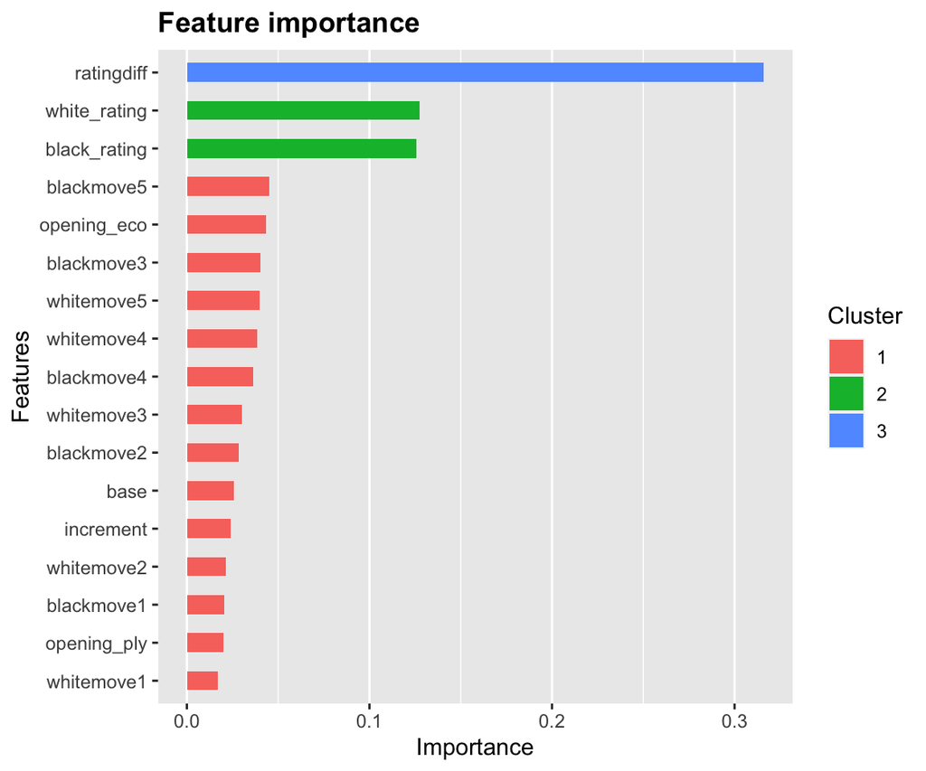

Importance of Features for Tuned Model: Full Sample

## Sub-samble by ELO

### Bottom Half

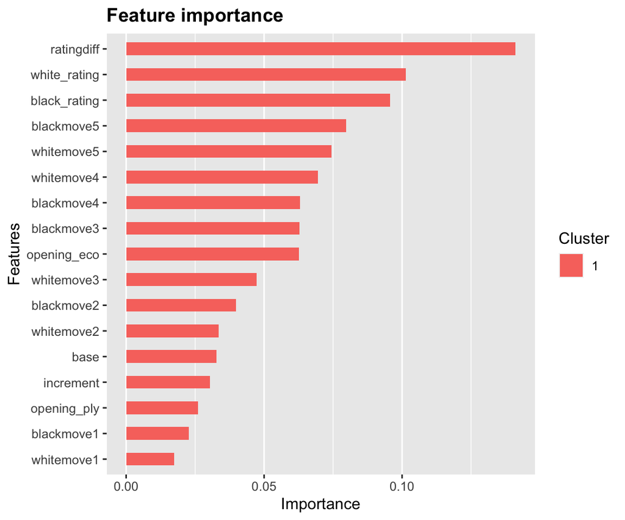

Feature Importance Untuned Model: Bottom Half

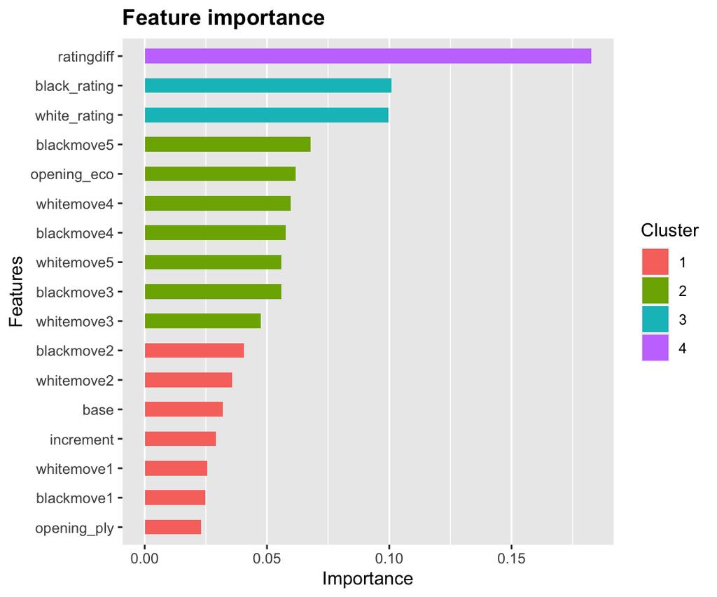

Feature Importance Tuned Model: Bottom Half

### Top Half

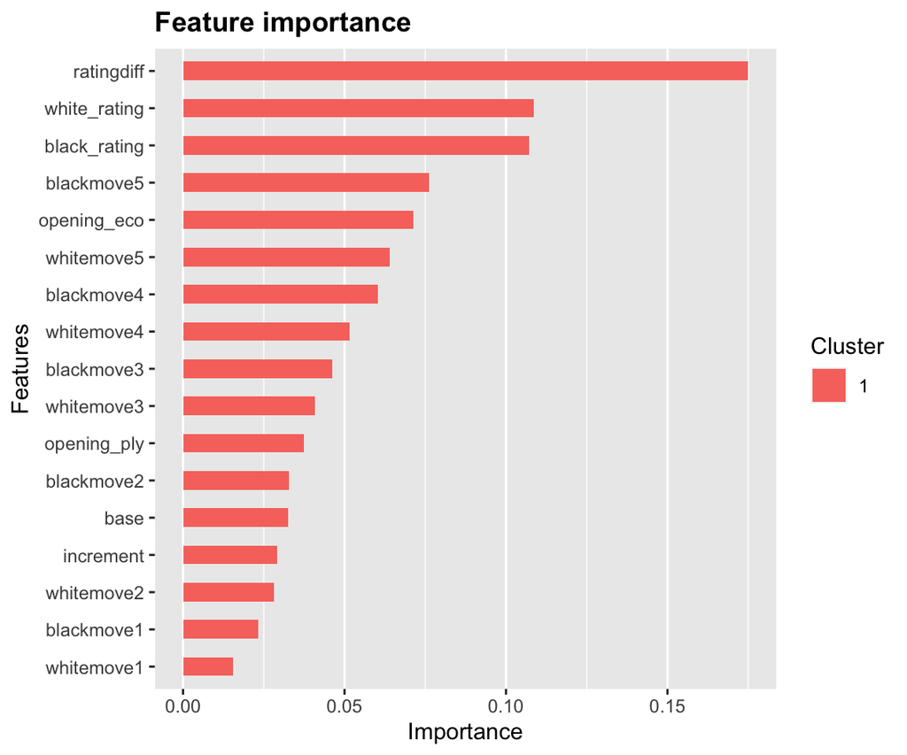

Feature Importance Untuned Model: Top Half

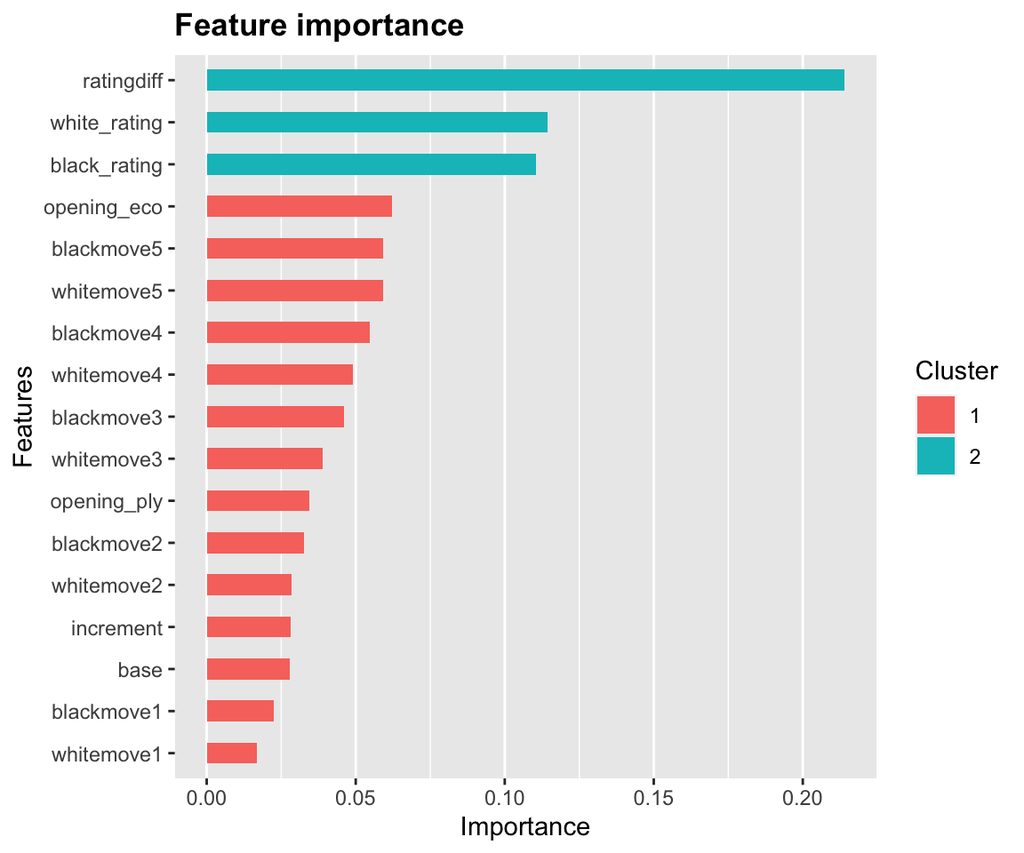

Feature Importance Tuned Model: Top Half

# References

[^1]: You can find my code on my Github page: https://github.com/wjwilliams/MLPROJ/tree/main/WriteUp